# Malle ERW — SoilR Posterior Correlation Plots

Plot-only report of existing posterior correlation analysis

Author

Teneille Nel

Published

November 4, 2026

# 1 Purpose and scope

This report regenerates and displays plots from the previously saved SoilR posterior correlation analysis.

The report does not: - Fit Bayesian models. - Calculate SoilR pool ages or system transit time. - Recalculate posterior correlations. - Write CSV, PNG, or PDF files.

All plots are displayed directly in the rendered HTML report.

The correlation analysis is based on five independent treatment-level observations. Posterior draws propagate uncertainty from the SoilR model, but do not increase the number of independent treatments. Correlations are exploratory and should not be interpreted as causal or as conventional significance tests.

# 2 1. Load existing statistical results

## 2.1 3.2 All rates, transfer coefficients, pool ages, and transit time

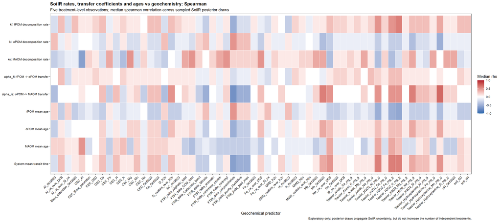

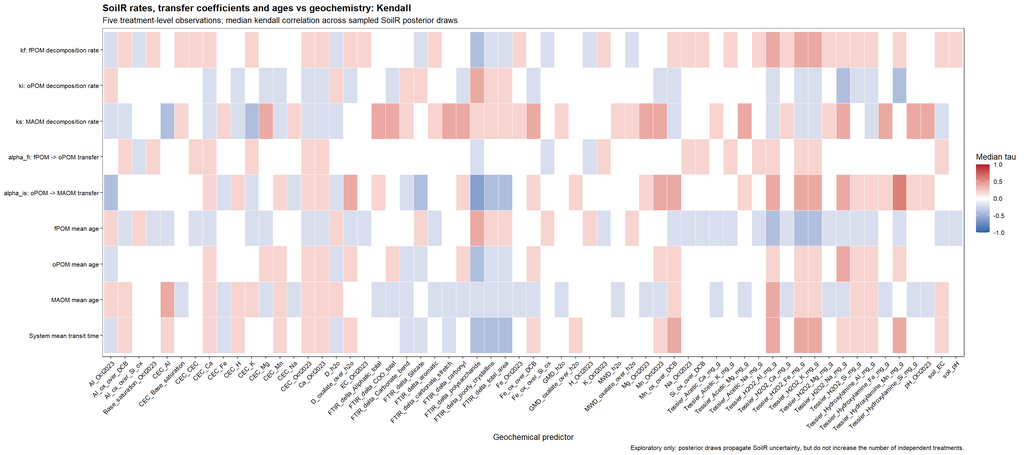

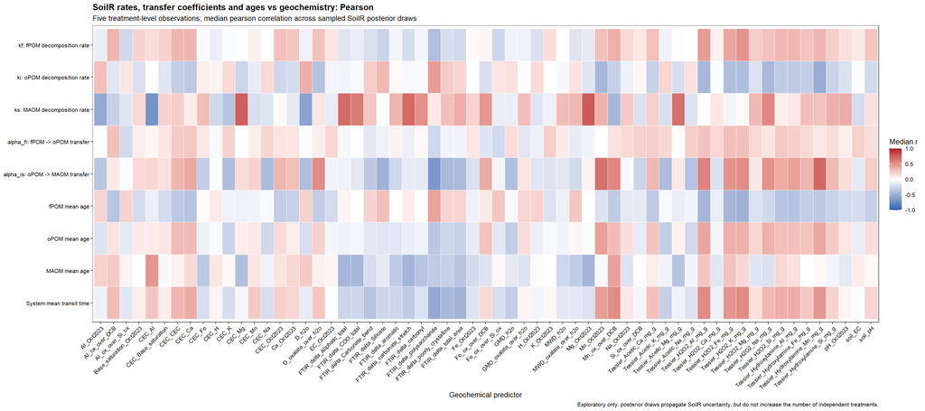

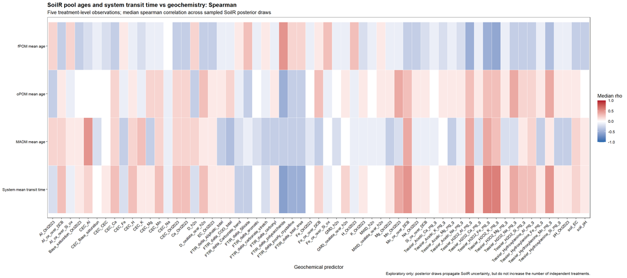

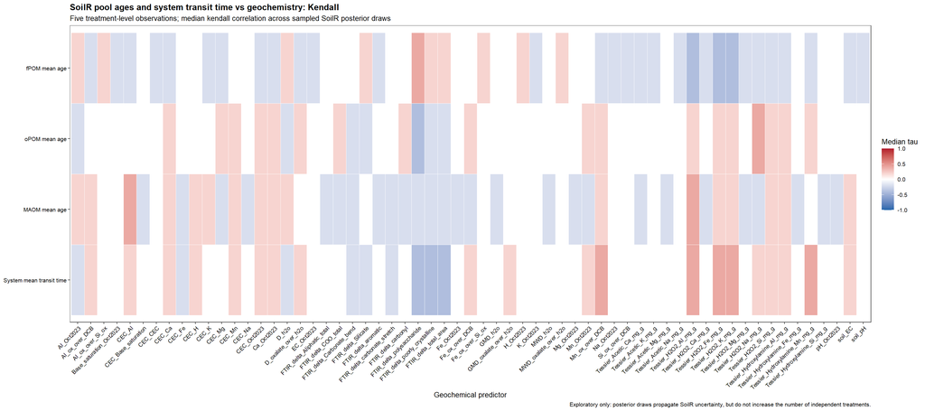

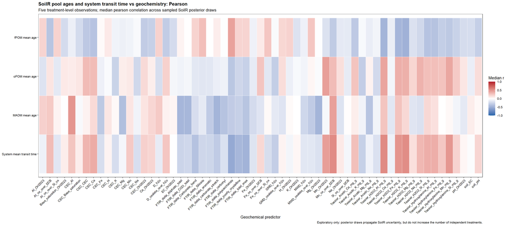

# 3 5. Strong persistence correlations — including FTIR and geochemical ratios

- Decomposition rates: kf, ki, ks
- Transfer coefficients: alpha_fi, alpha_is
- Pool ages: fPOM, oPOM, MAOM
- System mean transit time

A predictor is retained if it has at least one Spearman posterior median correlation with an absolute value of at least 0.5 across the nine outcomes.

Only cells with absolute median Spearman rho of at least 0.5 are displayed.

FTIR-derived variables, aggregate stability variables, and secondary-mineral ratios are not excluded.

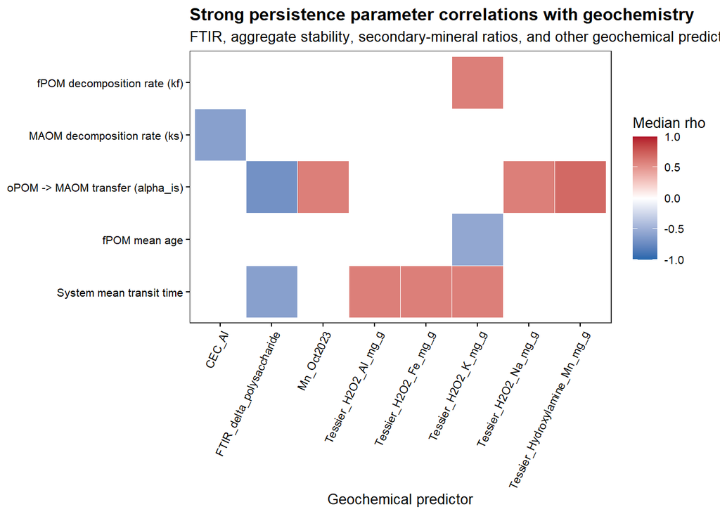